# Whirlpool

A work of Fiction, initially written sometime around late 2017

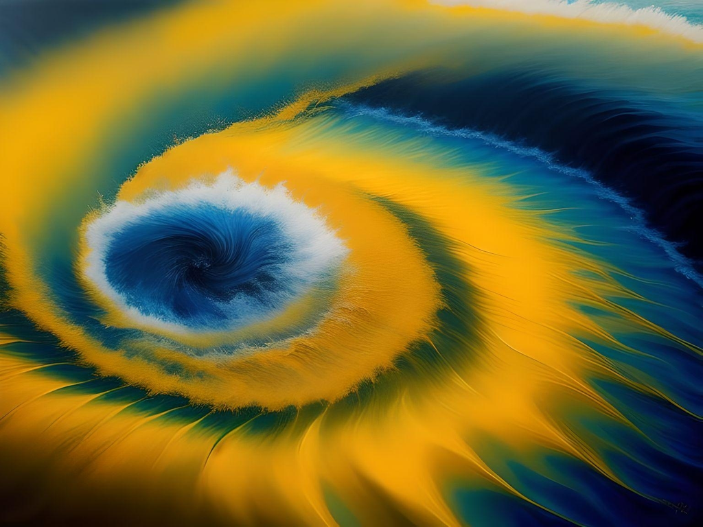

Troy wanted to take it back off, put it back in the box, and change back into his prison uniform. Really, he wanted to go back – back to the dorm, back to his bunk – but that feeling didn’t form into a conscious thought. It just stayed in the background as fear, a fear of going home that had been building for months.

It wasn’t that he didn’t like the outfit that his family had sent him for this “big day” – a simple combination of khaki pants and dress shirt – it was that the clothes felt unnatural, unsafe. He had put them on, with a feeling of surrealism, and walked out of the little room in the visitation park like a condemned man on the way to the gallows.

Now he was waiting. His family was outside; he could see their car in the parking lot, through the fences and wire. They were also waiting. To Troy, it felt like the whole world hung suspended on the edge of an abyss while the lieutenant, who had left him here, completed the last bit of mysterious processing that must be done before Troy would be a “free man”.

Troy just sat. He sat and stared at the floor. He focused on keeping his breathing even. Free, thought Troy. He shook his head in denial.

“Gavin? You still here?” The voice came from behind him. It was Officer Randall, the Inside Grounds supervisor. They knew each other slightly; Troy had been assigned extra duty with Randall once, a few years back.

“Yes sir.” Troy was confused. Was Randall here to tell him goodbye, to wish him good luck? He had obviously come to the visitation park looking for Troy specifically.

“I’ve got a piss test here for you. I’m glad I caught you before you left,” Randall said conversationally as he reached into a manila envelope. He extracted a little clear plastic jar with an orange lid and tossed it into the air. With a feeling of absolute terror, Troy watched the jar’s flight. It landed in Randall’s palm with the sound of a thunderclap, the sound of the earth cracking open for the entire world to fall into.

Troy had smoked some pot, for the first time in at least five years, just last night. He had thought it would help him sleep; it hadn’t, but he hadn’t known what else to do. He had been so nervous about going home he’d had less than three hours of sleep every night for weeks. He didn’t even think they did piss tests anymore. With there being so much synthetic trash in the prison system, next to no one tested positive for marijuana.

“But, I’m going home today…” Troy stammered.

“Not if you don’t pass this test, you’re not!” Randall countered with a casual, amused air; it was obvious that Randall hadn’t considered the possibility that Troy was dirty. “You fail this test, I gotta give ya the full clip: sixty days in the box and one-hundred eighty days loss gain-time. Could you imagine? That would suck! I don’t even know why ya’ll that’re going homes names’ appear on these lists, but this has happened a few times. Some computer in Tallahassee makes the lists. ‘Puter don’t care that you goin’ home. Ready?”

Troy watched himself take the jar from Randall’s hand. He didn’t know what else to do, so he just watched. He watched himself cross the visitation park to the bathroom. He watched himself open the door and step inside. Troy instinctively tried to shut the door behind him, to lock himself away from the world until he could come to terms with what was going on, but of course, Randall was right behind him.

“Alright, pants and boxers all the way down around your ankles, you know the drill.” Randall instructed matter-of-factly.

Troy did as he was told. He stood in front of the toilet with a jar in one hand and his penis in the other. He stood there like that for several moments, staring at this strange tableau: toilet, jar, penis, and khaki pants bunched up around his ankles. There were plaid boxers too. Plaid boxers? I’m supposed to go home today, Troy recalled numbly.

“I bet you’re ready to go, how long you been down?” Randall asked. His voice seemed to boom off the walls of the tiny bathroom. He was standing less than three feet from Troy.

“Um, nineteen years,” Troy replied emptily. Really, he’d been locked up for eighteen years and nine months, but the difference didn’t seem to matter to Troy much. Not now.

“Shit man, I can’t imagine how you must feel. Where you goin’?” Randall asked casually, as though he was out having a beer with Troy and not standing next to him while he tried to urinate into a plastic jar.

“Vermont. My folks drove down to pick me up…” Troy was starting to feel like he might pass out. Everything was spinning. A few drops of urine spread across the bottom of the jar, then a spurt. As Troy began to urinate fully, he watched the urine. The jar caused it to follow a circular path; it was a counterclockwise yellow whirlpool of piss.

Apparently, the urine was swirling in the opposite direction as the room, because Troy felt steadied in watching it.

“Vermont! Hey, that’s enough piss. Go ahead and cap that jar and clean up.” Randall told him. “Man, you better not come back to this shit. Got a family up in Vermont…”

Troy was beginning to get his bearings now. As Randall placed the jar on the visitation park table and prepared the testing kit, Troy began to think about how he could smooth talk Randall into helping him get through this last barrier to freedom. Randall, after all, was a human being. Troy was sure he’d understand. He could talk to Randall.

Maybe he wouldn’t even have to. Maybe it hadn’t been long enough for the drug to get to his urine. Maybe the test wouldn’t work.

“How does that thing work?” Troy asked.

Just then, the lieutenant came back into the room. Troy had forgotten about him. Troy felt his heart stop; a hole opened up where his stomach used to be, and he fell into that hole. He had no hope of talking his way out of this now…“Well,” Randall replied, oblivious to Troy’s internal death, “when the piss hits this paper here, it either gets a line across it if you are clean or no line if you are dirty. That line should pop up here right away… Well, we’ll just give it a second…

”The lieutenant came over and peered down onto the test as well. There was a long, silent pause as the three men contemplated the tiny piece of plastic-enclosed urine-soaked paper. No line appeared.

“You dirty son?” the lieutenant finally asked Troy.

“I, um… yeah. I smoked a little pot last night so that I could sleep. I didn’t even really get high… I just needed to sleep…” Troy was sure they would understand. It was just a little pot, they would understand.

After another long, full silence, the lieutenant sighed. He turned to Randall and said, “Cuff him up. Shit. He probably wouldn’t have made it three months out there anyhow.”

Troy turned away and put his hands behind his back. He turned away in anger; he turned away in shame. He was now facing the parking lot. Through the window he saw his father and daughter standing outside his father’s car. He saw them through the fences and the wire. He hadn’t known his daughter was going to be there… Who was the young child with her?

Troy wondered, Am I a grandfather? He hadn’t seen or heard from her in years… What would she think of him now? What was their ride back across the country going to be like? Would he ever see her again? Her image blurred through his tears. Randall’s handcuffs felt familiar. The sound of their tightening comforted him, somehow fortified him. This realization disgusted Troy.

Troy could hear the lieutenant on the telephone behind him, “Yeah, I know, world’s dumbest criminal, right? The paperwork is going to be a nightmare; someone’s got to tell the family…huh? I hadn’t thought of that…”

A long pause…

“Okay, yeah, no problem… Yeah.” The lieutenant sounded disappointed. Click.

“Randall, you gotta take those cuffs back offa him. I don’t know what I was thinking,” The lieutenant chuckled.

As the handcuffs were removed, Troy felt hope surge into his heart. Was this what it took Troy to finally realize that he did want to go home? If so, he was grateful. He now knew he was ready. He had imagined himself walking through the gates thousands of times; now he imagined himself, for the first time, walking through the gates with a smile on his face. I’m going home! Troy triumphantly announced to himself. Troy rubbed the marks on his wrists that the handcuffs had left behind. “He’s gotta take that bullshit back off. I can’t take him to the box dressed like that.” The lieutenant said. “You hear that, dummy? Put your uniform back on!”